# Experiment 1 Pilot Data Integrity

Dave Braun

July 19, 2019

# Practice Cued Task Switching

The data can be viewed below:

```r
d <- read.csv('../data/pracCued.csv')
d <- d %>%
  group_by(workerId) %>%
  summarize(dummy = n()) %>%
  mutate(subject = 1:(nrow(.))) %>%
  select(-dummy) %>%
  inner_join(d) %>%
  select(-workerId) %>%
  rename(workerId = subject)
d
```

| workerId | cuedRunTime | windowWidth | redTask | curId | screenHeight | blueTask | curTime | windowHeight | phase | userAgent | screenWidth | runTimeMins | rt | transition | taskCode | rsi | stimulus | trialCount | stimColor | error | responseKey |
| --- | --- | --- | --- | --- | --- | --- | --- | --- | --- | --- | --- | --- | --- | --- | --- | --- | --- | --- | --- | --- | --- |
| 1 | 374148 | 1348 | par | 3P529IW9KZ5KRZ5BZ1MJTFOBEN6FLC | 900 | mag | 16/07/2019@17:24:06 | 675 | pracCued | Mozilla/5.0 (Macintosh; Intel Mac OS X 10_14) AppleWebKit/605.1.15 (KHTML, like Gecko) Version/12.0 Safari/605.1.15 | 1440 | 3 | 13945 | startBlock | par | 200 | 9 | 1 | red | 0 | j |
| 1 | 374148 | 1348 | par | 3P529IW9KZ5KRZ5BZ1MJTFOBEN6FLC | 900 | mag | 16/07/2019@17:24:06 | 675 | pracCued | Mozilla/5.0 (Macintosh; Intel Mac OS X 10_14) AppleWebKit/605.1.15 (KHTML, like Gecko) Version/12.0 Safari/605.1.15 | 1440 | 3 | 3107 | switch | mag | 200 | 4 | 2 | blue | 0 | j |
| 1 | 374148 | 1348 | par | 3P529IW9KZ5KRZ5BZ1MJTFOBEN6FLC | 900 | mag | 16/07/2019@17:24:06 | 675 | pracCued | Mozilla/5.0 (Macintosh; Intel Mac OS X 10_14) AppleWebKit/605.1.15 (KHTML, like Gecko) Version/12.0 Safari/605.1.15 | 1440 | 3 | 601 | repeat | mag | 200 | 4 | 3 | blue | 0 | j |
| 1 | 374148 | 1348 | par | 3P529IW9KZ5KRZ5BZ1MJTFOBEN6FLC | 900 | mag | 16/07/2019@17:24:06 | 675 | pracCued | Mozilla/5.0 (Macintosh; Intel Mac OS X 10_14) AppleWebKit/605.1.15 (KHTML, like Gecko) Version/12.0 Safari/605.1.15 | 1440 | 3 | 1993 | switch | par | 200 | 3 | 4 | red | 0 | j |
| 1 | 374148 | 1348 | par | 3P529IW9KZ5KRZ5BZ1MJTFOBEN6FLC | 900 | mag | 16/07/2019@17:24:06 | 675 | pracCued | Mozilla/5.0 (Macintosh; Intel Mac OS X 10_14) AppleWebKit/605.1.15 (KHTML, like Gecko) Version/12.0 Safari/605.1.15 | 1440 | 3 | 842 | switch | mag | 200 | 2 | 5 | blue | 0 | j |
| 1 | 374148 | 1348 | par | 3P529IW9KZ5KRZ5BZ1MJTFOBEN6FLC | 900 | mag | 16/07/2019@17:24:06 | 675 | pracCued | Mozilla/5.0 (Macintosh; Intel Mac OS X 10_14) AppleWebKit/605.1.15 (KHTML, like Gecko) Version/12.0 Safari/605.1.15 | 1440 | 3 | 1010 | repeat | mag | 200 | 8 | 6 | blue | 0 | k |
| 1 | 374148 | 1348 | par | 3P529IW9KZ5KRZ5BZ1MJTFOBEN6FLC | 900 | mag | 16/07/2019@17:24:06 | 675 | pracCued | Mozilla/5.0 (Macintosh; Intel Mac OS X 10_14) AppleWebKit/605.1.15 (KHTML, like Gecko) Version/12.0 Safari/605.1.15 | 1440 | 3 | 545 | repeat | mag | 200 | 8 | 7 | blue | 0 | k |
| 1 | 374148 | 1348 | par | 3P529IW9KZ5KRZ5BZ1MJTFOBEN6FLC | 900 | mag | 16/07/2019@17:24:06 | 675 | pracCued | Mozilla/5.0 (Macintosh; Intel Mac OS X 10_14) AppleWebKit/605.1.15 (KHTML, like Gecko) Version/12.0 Safari/605.1.15 | 1440 | 3 | 1216 | switch | par | 200 | 1 | 8 | red | 0 | j |
| 1 | 374148 | 1348 | par | 3P529IW9KZ5KRZ5BZ1MJTFOBEN6FLC | 900 | mag | 16/07/2019@17:24:06 | 675 | pracCued | Mozilla/5.0 (Macintosh; Intel Mac OS X 10_14) AppleWebKit/605.1.15 (KHTML, like Gecko) Version/12.0 Safari/605.1.15 | 1440 | 3 | 871 | switch | mag | 200 | 3 | 9 | blue | 0 | j |
| 1 | 374148 | 1348 | par | 3P529IW9KZ5KRZ5BZ1MJTFOBEN6FLC | 900 | mag | 16/07/2019@17:24:06 | 675 | pracCued | Mozilla/5.0 (Macintosh; Intel Mac OS X 10_14) AppleWebKit/605.1.15 (KHTML, like Gecko) Version/12.0 Safari/605.1.15 | 1440 | 3 | 3486 | switch | par | 200 | 2 | 10 | red | 0 | k |

[output cut: 470 more lines]

I did a visual inspection in Excel, and things appear to be coded correctly. But I’ll verify that for a few variables here.

### Transition

This should map on directly to `stimColor` in the data.

```r
t <- d %>%
  mutate(transCheck = ifelse(trialCount == 1, 'startBlock', ifelse(stimColor == shift(stimColor), 'repeat', ifelse(stimColor != shift(stimColor), 'switch', ''))))

sum(t$transCheck == t$transition) == nrow(d)
```

```
## [1] TRUE
```

```r
d %>%
  filter(transition != 'startBlock') %>%
  group_by(workerId, transition) %>%
  summarize('Number of Trials' = n())
```

| workerId | transition | Number of Trials |
| --- | --- | --- |
| 1 | repeat | 84 |
| 1 | switch | 75 |
| 2 | repeat | 90 |
| 2 | switch | 69 |
| 3 | repeat | 86 |
| 3 | switch | 73 |

A few more repetitions per switches, but still within the range of what would be expected on a .5 probability.

### Error

```r
t <- d %>%
  mutate(errorCheck = ifelse(taskCode == 'mag' & stimulus < 5 & responseKey == 'k', 1,
                             ifelse(taskCode == 'mag' & stimulus > 5 & responseKey == 'j', 1,
                                    ifelse(taskCode == 'par' & stimulus %% 2 == 1 & responseKey == 'k', 1,
                                    ifelse(taskCode == 'par' & stimulus %% 2 == 0 & responseKey == 'j', 1, 0)))))
sum(t$errorCheck == t$error) == nrow(d)
```

```
## [1] TRUE
```

### Timing Check

```r
d %>%
  group_by(workerId) %>%
  summarize(TimeMins = max(runTimeMins))
```

| workerId | TimeMins |
| --- | --- |
| 1 | 6 |
| 2 | 7 |
| 3 | 7 |

### RT Check

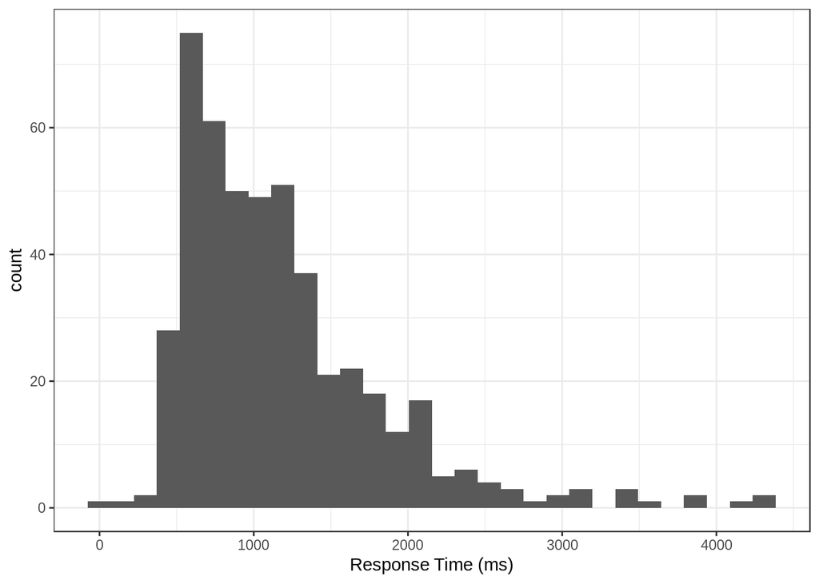

```r
d %>%
  filter(rt < 10000) %>%
  ggplot(aes(x = rt)) + geom_histogram() + xlab('Response Time (ms)') + theme_bw()
```

Looks good.

### Switch Cost

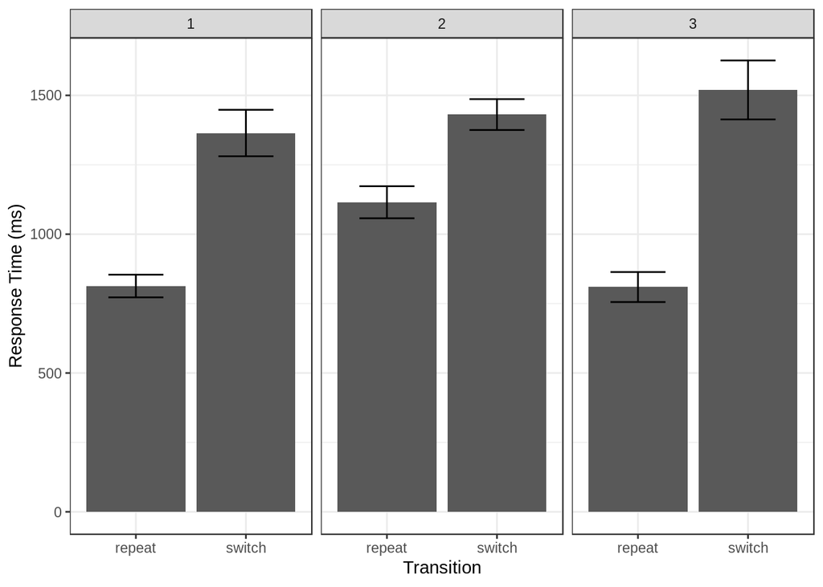

```r
d %>%
  mutate(errorTrim = ifelse(error | shift(error), 1, 0)) %>%
  filter(error == 0, errorTrim == 0, rt < 10000, transition != 'startBlock') %>%
  group_by(workerId, transition) %>%
  summarize(rtime = mean(rt), se = sd(rt) / sqrt(n())) %>%
  ggplot(aes(x = transition, y = rtime)) +
  geom_bar(stat = 'identity') +
  geom_errorbar(aes(ymin = rtime - se, ymax = rtime + se), width = 0.5) +
  facet_wrap(~workerId) +
  xlab('Transition') + ylab('Response Time (ms)') +
  theme_bw()
```

# Demand Selection Task

## Performance Data

```r
d <- read.csv('../data/dst.csv')
d <- d %>%
  group_by(workerId) %>%
  summarize(dummy = n()) %>%
  mutate(subject = 1:(nrow(.))) %>%
  select(-dummy) %>%
  inner_join(d) %>%
  select(-workerId) %>%
  rename(workerId = subject)
d
```

| workerId | windowWidth | redTask | curId | screenHeight | blueTask | curTime | windowHeight | phase | userAgent | screenWidth | phaseRunTime | blockTime | cycle | cuedRt | difficulty | leftDeckSwitch | condition | chosenDeckId | rightDeckId | rightDeckSwitch | experimentRunTimeMins | choiceResponseKey | stimColor | cuedResponseKey | difference | chosenDeckLocation | task | choiceRt | stimulus | … |
| --- | --- | --- | --- | --- | --- | --- | --- | --- | --- | --- | --- | --- | --- | --- | --- | --- | --- | --- | --- | --- | --- | --- | --- | --- | --- | --- | --- | --- | --- | --- |
| 1 | 1390 | par | 3P529IW9KZ5KRZ5BZ1MJTFOBEN6FLC | 900 | mag | 16/07/2019@17:44:29 | 675 | dst | Mozilla/5.0 (Macintosh; Intel Mac OS X 10_14) AppleWebKit/605.1.15 (KHTML, like Gecko) Version/12.0 Safari/605.1.15 | 1440 | 1222149 | 131.511 | 1 | 4491 | Easier than Reference | 0.1 | EE | EE | reference | 0.5 | 8 | D | red | K | Extreme | left | par | 3093 | 6 | … |
| 1 | 1390 | par | 3P529IW9KZ5KRZ5BZ1MJTFOBEN6FLC | 900 | mag | 16/07/2019@17:44:29 | 675 | dst | Mozilla/5.0 (Macintosh; Intel Mac OS X 10_14) AppleWebKit/605.1.15 (KHTML, like Gecko) Version/12.0 Safari/605.1.15 | 1440 | 1222149 | 131.511 | 1 | 513 | Easier than Reference | 0.1 | EE | EE | reference | 0.5 | 8 | D | red | K | Extreme | left | par | 808 | 6 | … |
| 1 | 1390 | par | 3P529IW9KZ5KRZ5BZ1MJTFOBEN6FLC | 900 | mag | 16/07/2019@17:44:29 | 675 | dst | Mozilla/5.0 (Macintosh; Intel Mac OS X 10_14) AppleWebKit/605.1.15 (KHTML, like Gecko) Version/12.0 Safari/605.1.15 | 1440 | 1222149 | 131.511 | 1 | 1056 | Easier than Reference | 0.1 | EE | EE | reference | 0.5 | 8 | D | blue | K | Extreme | left | mag | 354 | 6 | … |
| 1 | 1390 | par | 3P529IW9KZ5KRZ5BZ1MJTFOBEN6FLC | 900 | mag | 16/07/2019@17:44:29 | 675 | dst | Mozilla/5.0 (Macintosh; Intel Mac OS X 10_14) AppleWebKit/605.1.15 (KHTML, like Gecko) Version/12.0 Safari/605.1.15 | 1440 | 1222149 | 131.511 | 1 | 1400 | Easier than Reference | 0.1 | EE | EE | reference | 0.5 | 8 | D | blue | J | Extreme | left | mag | 276 | 4 | … |
| 1 | 1390 | par | 3P529IW9KZ5KRZ5BZ1MJTFOBEN6FLC | 900 | mag | 16/07/2019@17:44:29 | 675 | dst | Mozilla/5.0 (Macintosh; Intel Mac OS X 10_14) AppleWebKit/605.1.15 (KHTML, like Gecko) Version/12.0 Safari/605.1.15 | 1440 | 1222149 | 131.511 | 1 | 1017 | Easier than Reference | 0.1 | EE | reference | reference | 0.5 | 8 | F | red | K | Extreme | right | par | 330 | 2 | … |
| 1 | 1390 | par | 3P529IW9KZ5KRZ5BZ1MJTFOBEN6FLC | 900 | mag | 16/07/2019@17:44:29 | 675 | dst | Mozilla/5.0 (Macintosh; Intel Mac OS X 10_14) AppleWebKit/605.1.15 (KHTML, like Gecko) Version/12.0 Safari/605.1.15 | 1440 | 1222149 | 131.511 | 1 | 3185 | Easier than Reference | 0.1 | EE | reference | reference | 0.5 | 8 | F | blue | K | Extreme | right | mag | 311 | 6 | … |
| 1 | 1390 | par | 3P529IW9KZ5KRZ5BZ1MJTFOBEN6FLC | 900 | mag | 16/07/2019@17:44:29 | 675 | dst | Mozilla/5.0 (Macintosh; Intel Mac OS X 10_14) AppleWebKit/605.1.15 (KHTML, like Gecko) Version/12.0 Safari/605.1.15 | 1440 | 1222149 | 131.511 | 1 | 800 | Easier than Reference | 0.1 | EE | reference | reference | 0.5 | 8 | F | blue | J | Extreme | right | mag | 323 | 3 | … |
| 1 | 1390 | par | 3P529IW9KZ5KRZ5BZ1MJTFOBEN6FLC | 900 | mag | 16/07/2019@17:44:29 | 675 | dst | Mozilla/5.0 (Macintosh; Intel Mac OS X 10_14) AppleWebKit/605.1.15 (KHTML, like Gecko) Version/12.0 Safari/605.1.15 | 1440 | 1222149 | 131.511 | 1 | 1059 | Easier than Reference | 0.1 | EE | reference | reference | 0.5 | 8 | F | red | J | Extreme | right | par | 310 | 1 | … |
| 1 | 1390 | par | 3P529IW9KZ5KRZ5BZ1MJTFOBEN6FLC | 900 | mag | 16/07/2019@17:44:29 | 675 | dst | Mozilla/5.0 (Macintosh; Intel Mac OS X 10_14) AppleWebKit/605.1.15 (KHTML, like Gecko) Version/12.0 Safari/605.1.15 | 1440 | 1222149 | 131.511 | 1 | 839 | Easier than Reference | 0.1 | EE | reference | reference | 0.5 | 8 | F | blue | K | Extreme | right | mag | 292 | 2 | … |
| 1 | 1390 | par | 3P529IW9KZ5KRZ5BZ1MJTFOBEN6FLC | 900 | mag | 16/07/2019@17:44:29 | 675 | dst | Mozilla/5.0 (Macintosh; Intel Mac OS X 10_14) AppleWebKit/605.1.15 (KHTML, like Gecko) Version/12.0 Safari/605.1.15 | 1440 | 1222149 | 131.511 | 1 | 1364 | Easier than Reference | 0.1 | EE | EE | reference | 0.5 | 8 | D | blue | K | Extreme | left | mag | 1302 | 7 | … |

[output cut: 2390 more lines]

### Transition

This should map on directly to `stimColor` in the data.

```r
t <- d %>%
  mutate(transCheck = ifelse(trial == 1, 'startBlock', ifelse(stimColor == shift(stimColor), 'repeat', ifelse(stimColor != shift(stimColor), 'switch', ''))))

sum(t$transCheck == t$transition) == nrow(d)
```

```
## [1] TRUE
```

### Error

```r
t <- d %>%
  mutate(errorCheck = ifelse(task == 'mag' & stimulus < 5 & tolower(cuedResponseKey) == 'k', 1,
                             ifelse(task == 'mag' & stimulus > 5 & tolower(cuedResponseKey) == 'j', 1,
                                    ifelse(task == 'par' & stimulus %% 2 == 1 & tolower(cuedResponseKey) == 'k', 1,
                                    ifelse(task == 'par' & stimulus %% 2 == 0 & tolower(cuedResponseKey) == 'j', 1, 0)))))
sum(t$errorCheck == t$error) == nrow(d)
```

```
## [1] TRUE
```

### Timing Check

```r
d %>%
  group_by(workerId) %>%
  summarize(TimeMins = max(experimentRunTimeMins) - min(experimentRunTimeMins))
```

| workerId | TimeMins |
| --- | --- |
| 1 | 19 |
| 2 | 165 |
| 3 | 30 |

Worker 2 left and came back to the experiment.

### RT Check

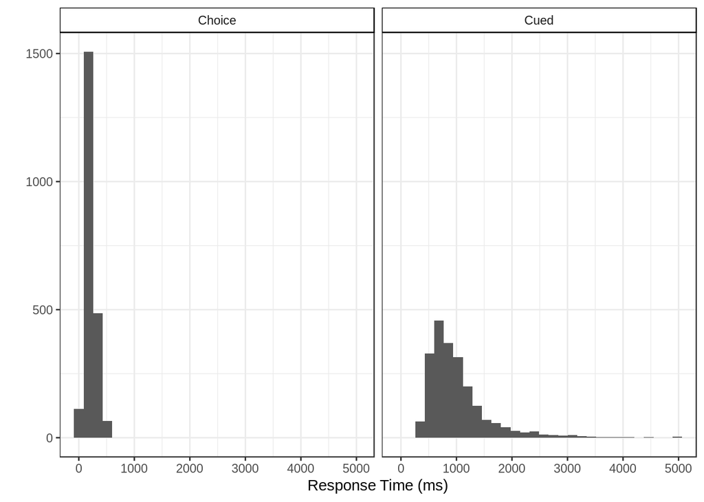

```r
d %>%
  filter(cuedRt < 5000, choiceRt < 500) %>%
  gather(var, rt, cuedRt, choiceRt) %>%
  mutate(var = factor(var)) %>%
  mutate(var = recode(var, "choiceRt" = "Choice", "cuedRt" = "Cued")) %>%
  ggplot(aes(x = rt)) + geom_histogram() +
  facet_wrap(~var) +
  xlab('Response Time (ms)') + ylab('') +
  theme_bw() +
  theme(strip.background = element_rect(fill = 'white', color = 'black'))
```

Choice RTs are fast.

## Choice

### Check Left / Right Coding

```r
t <- d %>%
  mutate(keyCheck = ifelse(tolower(choiceResponseKey) == 'd', 'left', ifelse(tolower(choiceResponseKey) == 'f', 'right', '')))

sum(t$keyCheck == t$chosenDeckLocation) == nrow(t)
```

```
## [1] TRUE
```

### Check Condition Cycling

```r
d %>%
  group_by(workerId, cycle, block) %>%
  summarize(condition = unique(condition))
```

| workerId | cycle | block | condition |
| --- | --- | --- | --- |
| 1 | 1 | 1 | EE |
| 1 | 1 | 2 | HE |
| 1 | 1 | 3 | HM |
| 1 | 1 | 4 | EM |
| 1 | 2 | 1 | EM |
| 1 | 2 | 2 | EE |
| 1 | 2 | 3 | HE |
| 1 | 2 | 4 | HM |
| 2 | 1 | 1 | EM |
| 2 | 1 | 2 | HE |

[output cut: 14 more lines]

```r
d %>%
  group_by(workerId, cycle, block) %>%
  summarize(leftDeckId = unique(leftDeckId), rightDeckId = unique(rightDeckId))
```

| workerId | cycle | block | leftDeckId | rightDeckId |
| --- | --- | --- | --- | --- |
| 1 | 1 | 1 | EE | reference |
| 1 | 1 | 2 | HE | reference |
| 1 | 1 | 3 | HM | reference |
| 1 | 1 | 4 | EM | reference |
| 1 | 2 | 1 | reference | EM |
| 1 | 2 | 2 | reference | EE |
| 1 | 2 | 3 | HE | reference |
| 1 | 2 | 4 | HM | reference |
| 2 | 1 | 1 | reference | EM |
| 2 | 1 | 2 | reference | HE |

[output cut: 14 more lines]

I’m struggling to think of which other assumptions of stimulus presentation need to be checked.

### Looking at some Choice Data

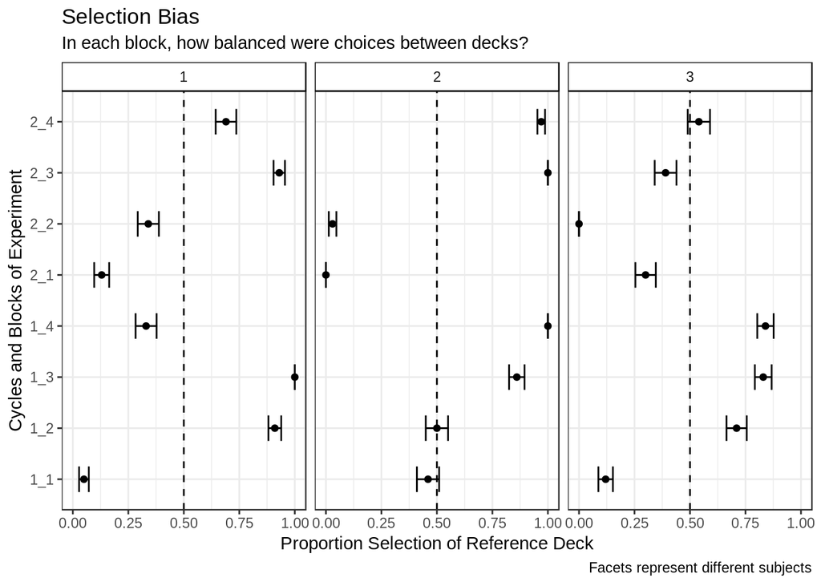

```r
d <- d %>%
  mutate(selectedReferenceDeck = ifelse(chosenDeckId == 'reference', 1, 0))

d %>%
  unite(cycle_block, cycle, block) %>%
  mutate(workerId = factor(workerId)) %>%
  #mutate(workerId = recode(workerId, `1` = 'Subject 1', `2` = 'Subject 2')) %>%  # this line won't be reproducible with larger sample
  group_by(workerId, cycle_block) %>%
  summarize(selRefDeck = mean(selectedReferenceDeck), se = sd(selectedReferenceDeck) / sqrt(n())) %>%
  ggplot(aes(x = cycle_block, y = selRefDeck)) +
  geom_point() +
  geom_errorbar(aes(ymin = selRefDeck - se, ymax = selRefDeck + se), width = 0.5) +
  coord_flip() +
  facet_wrap(~workerId) +
  xlab('Cycles and Blocks of Experiment') +
  ylab('Proportion Selection of Reference Deck') +
  theme_bw() +
  theme(strip.background = element_rect(fill = 'white', color = 'black')) +
  geom_hline(yintercept = 0.5, linetype = 'dashed') +
  labs(title = 'Selection Bias', subtitle = 'In each block, how balanced were choices between decks?', caption = 'Facets represent different subjects')
```

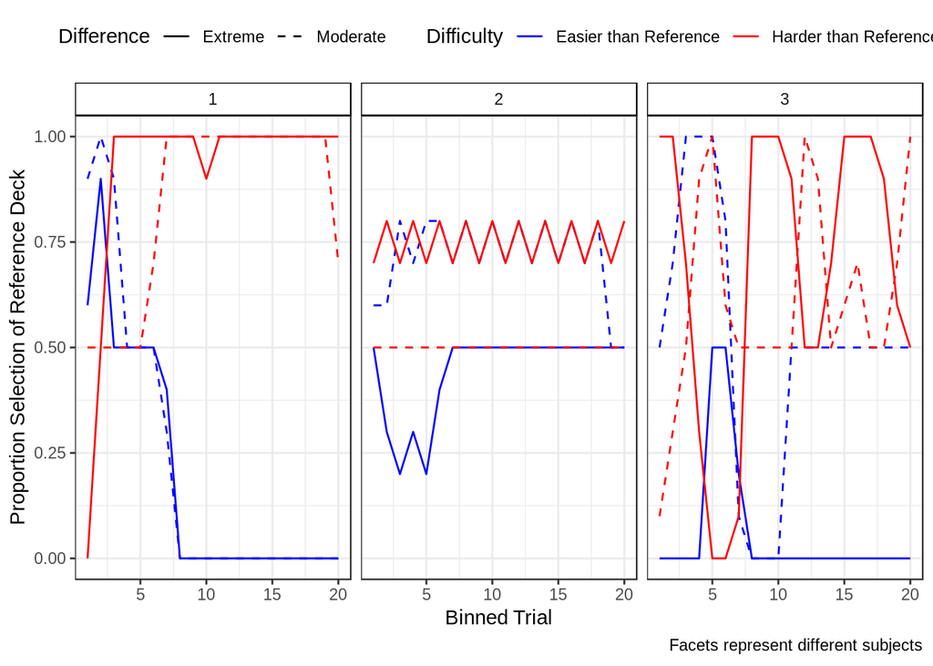

```r
 d %>%
  mutate(trialBucket = as.numeric(cut(trial, breaks = seq(0, 100, by = 5)))) %>%
  group_by(workerId, condition, difference, difficulty, trialBucket) %>%
  summarize(selRefDeck = mean(selectedReferenceDeck)) %>%
  ggplot(aes(x = trialBucket, y = selRefDeck, group = condition)) +
  geom_line(aes(color = difficulty, linetype = difference)) +
  facet_wrap(~workerId) +
  theme_bw()+
  theme(legend.position = 'top',
        strip.background = element_rect(fill = 'white', color = 'black')) +
  scale_color_manual(name = 'Difficulty', breaks = c('Easier than Reference', 'Harder than reference'), values = c('Blue', 'Red'), labels = c('Easier than Reference', 'Harder than Reference')) +
  scale_linetype_manual(name = 'Difference', labels = c('Extreme', 'Moderate'), values = c('solid', 'dashed')) +
  xlab('Binned Trial') +
  ylab('Proportion Selection of Reference Deck') +
  labs(caption = 'Facets represent different subjects')
```

That Subject 1 data is beautiful. I just want to make sure I have what I need to set up the critical 2 X 2… not that I wanna peek at the effects just yet.

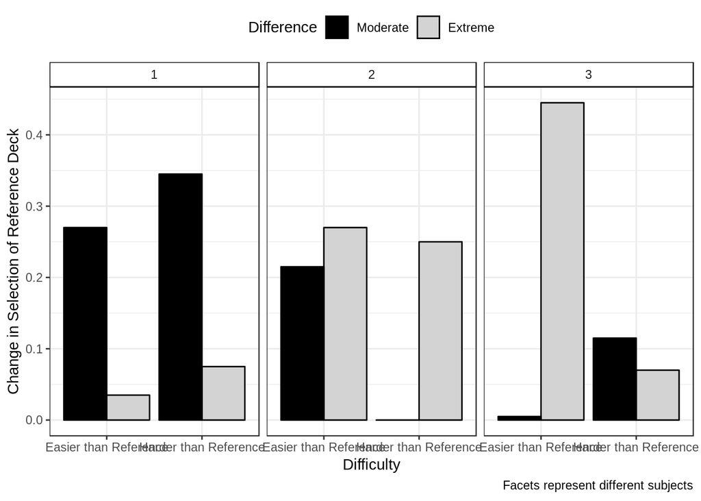

```r
condTable <- data.frame(condition = c('EE','EM','HE','HM'), difficulty = c(rep('Easier than Reference', 2), rep('Harder than Reference', 2)), difference = rep(c('Extreme', 'Moderate'), 2))
d %>%
  group_by(workerId, condition) %>%
  summarize(selRefDeck = mean(selectedReferenceDeck)) %>%
  spread(condition, selRefDeck) %>%
  mutate(EEDEV = abs(EE - EM), EMDEV = abs(EM - 0.5), HMDEV = abs(HM - 0.5), HEDEV = abs(HE - HM)) %>%
  select(-(EE:HM)) %>%
  gather(condition, selRefDeck, contains('DEV')) %>%
  mutate(condition = str_replace(condition, 'DEV', '')) %>%
  inner_join(condTable) %>%
  select(-condition) %>%
  mutate(difference = factor(difference, levels = levels(factor(difference))[c(2,1)])) %>%
  ggplot(aes(x = difficulty, y = selRefDeck, group = difference)) +
  geom_bar(stat = 'identity', aes(fill = difference), position = position_dodge(width = .9), color = 'black') +
  facet_wrap(~workerId) +
  theme_bw() +
  xlab('Difficulty') +
  ylab('Change in Selection of Reference Deck') +
  labs(caption = 'Facets represent different subjects') +
  scale_fill_manual(name = 'Difference', values = c(Moderate = 'Black', Extreme = 'Light Grey')) +
  theme(strip.background = element_rect(fill = 'white', color = 'black'),
        legend.position = 'top')
```

Subject 1 is really making me look. Subject 2 indicated that he / she didn’t understand the instructions relating to choosing between decks. Maybe I’ll add an extra note about that between blocks.

A work by [Dave Braun](https://davebraun.org)

*dab414@lehigh.edu*